# Group Project_Data Viz

Navyasree Madhu

2024-10-12

## The Great Americal Coffee Taste test

**A breakdown of ‘The Great American Coffee Taste Test’ data specifically looking to explore relationships between demographics and taste preferences**

**Abstract**

The chosen data-set for this project is “The Great American Coffee Taste Test” from TidyTuesday (Week 21, 2024). In October 2023, “world champion barista” James Hoffmann and coffee company Cometeer held the “Great American Coffee Taste Test” on YouTube, during which viewers were asked to fill out a survey about 4 coffees they ordered from Cometeer for the tasting. Based on the research conducted by the NIH: National Institutes of Health, which found that 75% of U.S. adults over the age of 20 drink coffee, with 49% drinking it daily, coffee consumption is clearly a significant part of American culture and daily life. This widespread prevalence of coffee consumption makes it an ideal subject for data analysis, as it offers insights into behavior patterns that affect a large portion of the population.

Understanding the coffee consumption habits of individuals offers valuable insights into consumer behavior, lifestyle preferences, and spending patterns. Coffee is an integral part of daily life for many people around the world, and studying why people choose to drink coffee, their preferred roast, where they typically consume it, and how much they spend can reveal a lot about personal tastes, habits, and economic factors. These factors could also provide valuable information for businesses in the coffee industry, helping them tailor their products and marketing strategies more effectively. People from different age groups or genders may gravitate toward specific coffee types (e.g., espresso, cappuccino, black coffee) and may prefer different levels of customization when it comes to additives. By exploring how age and gender impact these preferences, we can gain insight into how demographic characteristics shape coffee consumption patterns.

**Question 1: Why do people choose to drink coffee, what roast preference are common, where do they typically drink it, and how much do they spend on coffee overall?**

**Introduction**

We are interested in this question because analyzing coffee consumption habits provides valuable insights into consumer behavior, lifestyle choices, and spending trends. Coffee plays a significant role in the daily routines of people worldwide, and examining why individuals drink coffee, their preferred roast type, typical consumption locations, and spending amounts can shed light on personal preferences, habits, and economic influences. These insights could also be beneficial for businesses in the coffee industry, enabling them to better tailor their products and marketing strategies.

To explore this question, the essential attributes in the coffee dataset—total_spend, why_drink, where_drink, and roast_level—will offer a comprehensive view of coffee consumption patterns, revealing motivations, preferences, spending behavior, and lifestyle tendencies. We plan to use bar plots and box plots to visualize categorical data, such as reasons for drinking coffee (why_drink) and coffee roast preferences (roast_level), as well as to display the spending distribution by location (where_drink).

**Approach**

In order to answer our first question we choose a bar plot and heatmap.

The first part of question 1 focuses on understanding why people choose to drink coffee and identifying common roast preferences. In this study, we aim to illustrate relationships between multiple variables in a single plot. We selected a bar plot for this purpose due to its simplicity, flexibility, and ability to clearly highlight differences across categories. A bar plot offers a straightforward yet powerful way to present complex information in an organized and easily understandable format.

To address the second part of question 1, we used a heatmap. A heatmap is a valuable data visualization tool that employs color gradients to depict the intensity or magnitude of values within a dataset. This visual approach makes it easy to recognize complex data patterns and identify areas of high or low concentration. Here, we aim to discover the most popular locations for coffee consumption and how much people typically spend at each location.

```r
#Load required library

library(ggplot2)
library(dplyr)
library(tidyr)
library(networkD3)
```

**Analysis- Question No.1**

**Part 1**

```r
#Load the data

coffee_survey <- readr::read_csv('https://raw.githubusercontent.com/rfordatascience/tidytuesday/master/data/2024/2024-05-14/coffee_survey.csv')
# Remove rows with NA values in the important columns

coffee_sankey_clean <- na.omit(coffee_survey[, c("age", "gender", "favorite", "additions")])



coffee_Q1 <- coffee_survey[, c("why_drink", "roast_level", "total_spend", "where_drink")]


coffee_Q1 <- coffee_survey[, c("why_drink", "roast_level", "total_spend", "where_drink")]



na.omit(coffee_Q1)
```

```
## # A tibble: 3,503 × 4
##    why_drink                                 roast_level total_spend where_drink
##    <chr>                                     <chr>       <chr>       <chr>
##  1 It tastes good                            Light       $20-$40     At home, A…
##  2 It tastes good, I need the caffeine       Light       $40-$60     At home, A…
##  3 It tastes good                            Light       $20-$40     At the off…
##  4 It tastes good, I need the caffeine, I n… Dark        $40-$60     At home
##  5 I need the ritual, It tastes good         Blonde      $60-$80     At a cafe,…
##  6 It tastes good, I need the caffeine       Light       >$100       At home
##  7 It tastes good, I need the caffeine       Medium      $20-$40     At home, A…
##  8 It tastes good, I need the caffeine       Medium      <$20        At a cafe
##  9 It tastes good, I need the caffeine, I n… Medium      $20-$40     At home, A…
## 10 It tastes good, I need the ritual         Dark        $60-$80     At home
## # ℹ 3,493 more rows
```

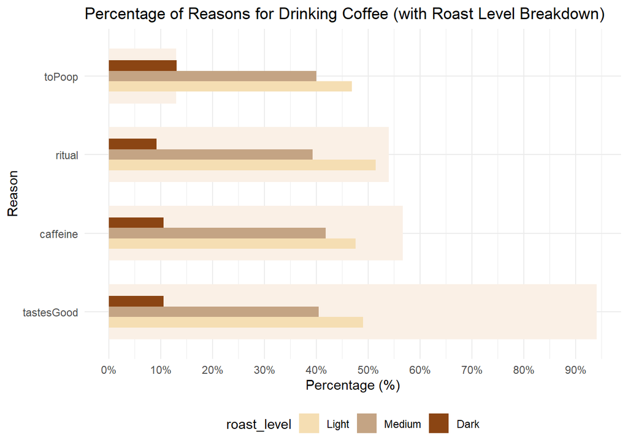

```r
coffee_Q1 <- na.omit(coffee_Q1[, c("why_drink", "roast_level", "total_spend", "where_drink")])



# Calculate total percentages for each reason
reason_counts <- coffee_Q1 %>%

  mutate(
    tastesGood = grepl("It tastes good", why_drink),
    ritual = grepl("I need the ritual", why_drink),
    caffeine = grepl("I need the caffeine", why_drink),
    toPoop = grepl("It makes me go to the bathroom", why_drink)
  ) %>%
  pivot_longer(cols = tastesGood :toPoop, names_to = "reason", values_to = "selected") %>%
  filter(selected) %>%
  count(reason) %>%
  mutate(percentage = (n / nrow(coffee_Q1)) * 100)


# Calculate percentages for each roast level within each reason

roast_level_counts <- coffee_Q1 %>%

  mutate(
    tastesGood = grepl("It tastes good", why_drink),
    ritual = grepl("I need the ritual", why_drink),
    caffeine = grepl("I need the caffeine", why_drink),
    toPoop = grepl("It makes me go to the bathroom", why_drink)
  ) %>%
  pivot_longer(cols = tastesGood:toPoop, names_to = "reason", values_to = "selected") %>%
  filter(selected) %>%
  filter(roast_level %in% c("Light", "Medium", "Dark")) %>%
  count(reason, roast_level) %>%
  group_by(reason) %>%
  mutate(percentage = (n / sum(n)) * 100)

# Define roast colors

roast_colors <- c("Light" = "wheat", "Medium" = "#C4A484", "Dark" = "chocolate4")

# Reorder roast_level to ensure proper order in bars and legend
roast_level_counts$roast_level <- factor(roast_level_counts$roast_level, levels = c("Light", "Medium", "Dark"))

# Plot original bars for reasons

p1 <- ggplot(reason_counts, aes(x = reorder(reason, -percentage), y = percentage)) +
  geom_bar(stat = "identity", fill = "#FAF0E6", position = position_dodge(width = 0.8), width = 0.7) +
  labs(title = "Percentage of Reasons for Drinking Coffee (with Roast Level Breakdown)",
       x = "Reason",
       y = "Percentage (%)") +
  scale_y_continuous(breaks = seq(0, 100, 10), labels = scales::percent_format(scale = 1)) +
  theme_minimal() +
  coord_flip()

# Add the roast level bars just above the original bars

p2 <- ggplot(roast_level_counts, aes(x = reorder(reason, +percentage), y = percentage, fill = roast_colors)) +
  geom_bar(stat = "identity", position = position_dodge(width = 0.6), width = 1) +
  scale_fill_manual(values = roast_colors, breaks = c("Light", "Medium", "Dark")) +
  theme_minimal() +
  coord_flip() +
  theme(axis.title.x = element_blank(), axis.text.x = element_blank(), axis.ticks.x = element_blank())

# Combine the two plots by overlaying them

p1 + geom_bar(data = roast_level_counts, aes(y = percentage, fill = roast_level),
              stat = "identity", position = position_dodge(width = 0.4), width = 0.4) +
  theme_minimal() +
  scale_fill_manual(values = roast_colors, breaks = c("Light", "Medium", "Dark")) +
  theme(legend.position = "bottom")
```

**Part-2**

```r
coffee_survey <- readr::read_csv('https://raw.githubusercontent.com/rfordatascience/tidytuesday/master/data/2024/2024-05-14/coffee_survey.csv')
head(coffee_survey)
```

```
## # A tibble: 6 × 57
##   submission_id age   cups  where_drink brew  brew_other purchase purchase_other
##   <chr>         <chr> <chr> <chr>       <chr> <chr>      <chr>    <chr>
## 1 gMR29l        18-2… <NA>  <NA>        <NA>  <NA>       <NA>     <NA>
## 2 BkPN0e        25-3… <NA>  <NA>        Pod/… <NA>       <NA>     <NA>
## 3 W5G8jj        25-3… <NA>  <NA>        Bean… <NA>       <NA>     <NA>
## 4 4xWgGr        35-4… <NA>  <NA>        Coff… <NA>       <NA>     <NA>
## 5 QD27Q8        25-3… <NA>  <NA>        Pour… <NA>       <NA>     <NA>
## 6 V0LPeM        55-6… <NA>  <NA>        Pod/… <NA>       <NA>     <NA>
## # ℹ 49 more variables: favorite <chr>, favorite_specify <chr>, additions <chr>,
## #   additions_other <chr>, dairy <chr>, sweetener <chr>, style <chr>,
## #   strength <chr>, roast_level <chr>, caffeine <chr>, expertise <dbl>,
## #   coffee_a_bitterness <dbl>, coffee_a_acidity <dbl>,
## #   coffee_a_personal_preference <dbl>, coffee_a_notes <chr>,
## #   coffee_b_bitterness <dbl>, coffee_b_acidity <dbl>,
## #   coffee_b_personal_preference <dbl>, coffee_b_notes <chr>, …
```